# Dataset.03: ISOLET

Additional Information

- This data set was generated as follows. 150 subjects spoke the name of each letter of the alphabet twice. Hence, we have 52 training examples from each speaker. The speakers are grouped into sets of 30 speakers each, and are referred to as isolet1, isolet2, isolet3, isolet4, and isolet5. The data appears in isolet1+2+3+4.data in sequential order, first the speakers from isolet1, then isolet2, and so on. The test set, isolet5, is a separate file.
- You will note that 3 examples are missing. I believe they were dropped due to difficulties in recording.
- I believe this is a good domain for a noisy, perceptual task. It is also a very good domain for testing the scaling abilities of algorithms. For example, C4.5 on this domain is slower than backpropagation!
- I have formatted the data for C4.5 and provided a C4.5-style names file as well.

```python
import pandas as pd

# data (as pandas dataframes)
train = pd.read_csv('isolet1+2+3+4.data', header = None)
test = pd.read_csv('isolet5.data', header = None)
```

The dataset is already separated as train and test. However, features and target are to be decoupled. As column 617 is the target column, next step is to get sets sorted accordingly.

```python
X_train = train.iloc[:, :617].copy()
y_train = train[617].copy()

X_test = test.iloc[:, :617].copy()
y_test = test[617].copy()

X = pd.concat([X_train, X_test], ignore_index=True).copy()
y = pd.concat([y_train, y_test], ignore_index=True).copy()

from sklearn.preprocessing import label_binarize
y_bnr = label_binarize(y, classes=list(sorted(y.value_counts().index)))
```

```python
print(len(X_train.columns))
print(y_train.value_counts())
```

[output not shown]

It is a multiclass dataset. There are 617 features in data. Dataset is balanced.

```python
X.describe()
```

|  | 0 | 1 | 2 | 3 | 4 | 5 | 6 | 7 | 8 | 9 | ... | 607 | 608 | 609 | 610 | 611 | 612 | 613 | 614 | 615 | 616 |
| --- | --- | --- | --- | --- | --- | --- | --- | --- | --- | --- | --- | --- | --- | --- | --- | --- | --- | --- | --- | --- | --- |
| count | 7797.000000 | 7797.000000 | 7797.000000 | 7797.000000 | 7797.000000 | 7797.000000 | 7797.000000 | 7797.000000 | 7797.000000 | 7797.000000 | ... | 7797.000000 | 7797.000000 | 7797.000000 | 7797.000000 | 7797.000000 | 7797.000000 | 7797.000000 | 7797.000000 | 7797.000000 | 7797.000000 |
| mean | -0.385396 | 0.141103 | 0.347384 | 0.450659 | 0.324283 | 0.163589 | 0.023852 | -0.081577 | -0.149191 | -0.191763 | ... | 0.370768 | 0.341730 | 0.311678 | 0.318904 | 0.334451 | 0.299238 | 0.224122 | 0.186668 | 0.081370 | -0.281416 |
| std | 0.236721 | 0.320090 | 0.326658 | 0.308301 | 0.461491 | 0.569970 | 0.559704 | 0.535142 | 0.528714 | 0.515343 | ... | 0.335582 | 0.330835 | 0.328813 | 0.333747 | 0.334954 | 0.334282 | 0.336135 | 0.337780 | 0.332859 | 0.354418 |
| min | -1.000000 | -0.892600 | -0.975200 | -0.968000 | -0.996600 | -1.000000 | -1.000000 | -1.000000 | -1.000000 | -1.000000 | ... | -0.609400 | -0.803400 | -0.775200 | -0.830200 | -0.711800 | -0.770800 | -0.810600 | -0.780200 | -0.802800 | -0.962600 |
| 25% | -0.546800 | -0.099400 | 0.105400 | 0.247800 | -0.024800 | -0.359600 | -0.461600 | -0.526800 | -0.577400 | -0.601200 | ... | 0.130400 | 0.098000 | 0.071400 | 0.073600 | 0.088600 | 0.049200 | -0.017800 | -0.057600 | -0.154600 | -0.546600 |
| 50% | -0.414000 | 0.106400 | 0.333400 | 0.453200 | 0.415800 | 0.204200 | -0.010800 | -0.154400 | -0.233200 | -0.261000 | ... | 0.366200 | 0.337400 | 0.294200 | 0.295000 | 0.315800 | 0.280000 | 0.192400 | 0.157800 | 0.045200 | -0.329000 |
| 75% | -0.241000 | 0.354600 | 0.583400 | 0.668600 | 0.692400 | 0.686200 | 0.492400 | 0.304400 | 0.190200 | 0.120000 | ... | 0.622600 | 0.588800 | 0.548800 | 0.565800 | 0.581600 | 0.541200 | 0.461600 | 0.410800 | 0.289800 | -0.065600 |
| max | 1.000000 | 1.000000 | 1.000000 | 1.000000 | 1.000000 | 1.000000 | 1.000000 | 1.000000 | 1.000000 | 1.000000 | ... | 1.000000 | 1.000000 | 1.000000 | 1.000000 | 1.000000 | 1.000000 | 1.000000 | 1.000000 | 1.000000 | 0.889800 |

8 rows × 617 columns

Dataset is already standardized.

```python
'''
from sklearn.model_selection import train_test_split

X_train,X_test,y_train,y_test = train_test_split(X,y,test_size=0.3)
'''
```

```python
'''
from sklearn.preprocessing import StandardScaler
scaler = StandardScaler()
X_train = scaler.fit_transform(X_train)
X_test = scaler.transform(X_test)
'''
```

```python
'''
from imblearn.combine import SMOTEENN

cnt_before = y_train.value_counts()

X_train_os, y_train_os = SMOTEENN().fit_resample(X_train, y_train)

cnt_after = y_train_os.value_counts()
print(cnt_before, cnt_after)
'''
```

## kNN

```python
import numpy as np
from sklearn.neighbors import KNeighborsClassifier
from sklearn.metrics import accuracy_score
```

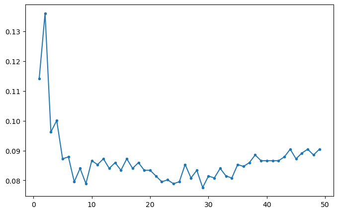

```python
import matplotlib.pyplot as plt
error_rate = []

for i in range(1,50):
    knn = KNeighborsClassifier(n_neighbors=i)
    knn.fit(X_train, y_train.values.ravel())
    y_pred_knn = knn.predict(X_test)
    error_rate.append(np.mean(y_pred_knn != y_test.values.ravel()))

plt.figure(figsize=(8,5))
plt.plot(range(1,50),error_rate, marker='o', markersize=3)
```

I selected 9 as n_neigbors.

```python
knn = KNeighborsClassifier(n_neighbors=9)
knn.fit(X_train, y_train.values.ravel())
y_pred_knn = knn.predict(X_test)
accuracy_score(y_test, y_pred_knn)
```

```
0.9211032713277743
```

## Decision Trees

```python
from sklearn.tree import DecisionTreeClassifier
```

```python
from sklearn.preprocessing import label_binarize
y_train_bnr = label_binarize(y_train, classes=list(sorted(y_train.value_counts().index)))
y_test_bnr = label_binarize(y_test, classes=list(sorted(y_test.value_counts().index)))
```

[output not shown]

```python
n_classes = y_train_bnr.shape[1]

res = []

min_samples_leafs = np.linspace(1, 11, 11, dtype = int,endpoint=True)
for i in range(5):
    for min_samples_leaf in min_samples_leafs:
        dt = DecisionTreeClassifier(min_samples_leaf = min_samples_leaf)
        dt.fit(X_train, y_train_bnr)
        y_test_dt = dt.predict(X_test)
        fpr = dict()
        tpr = dict()
        roc_auc = dict()
        lw=2
        for j in range(n_classes):
            fpr[j], tpr[j], _ = roc_curve(y_test_bnr[:, j], y_test_dt[:, j])
            roc_auc[j] = auc(fpr[j], tpr[j])

        avg_roc_auc = sum(roc_auc.values())/len(roc_auc)

        res.append([i, min_samples_leaf, avg_roc_auc])
        '''
        for k in range(n_classes):
            plt.plot(fpr[k], tpr[k], lw=2, #color = color,
                     label='{0}: ROC {0} (area = {1:0.2f})'
                     ''.format(min_samples_leaf, k, roc_auc[k]))
        plt.plot([0, 1], [0, 1], 'k--', lw=lw)
        plt.xlim([-0.05, 1.0])
        plt.ylim([0.0, 1.05])
        plt.xlabel('False Positive Rate')
        plt.ylabel('True Positive Rate')
        plt.title('Receiver operating characteristic for multi-class data')
        plt.legend(loc='center left', bbox_to_anchor=(1, 0.5))
        plt.show()
        '''
```

[output not shown]

[output cut: 41 more lines]

```python
res_df = pd.DataFrame(res, columns = ['cycle', 'min_samples_leaf', 'avg_roc_auc'])
res_df.groupby('min_samples_leaf')['avg_roc_auc'].mean().sort_values()
```

```
min_samples_leaf
7     0.883758
6     0.885498
8     0.885601
10    0.887766
9     0.888602
4     0.889578
2     0.890402
5     0.891571
11    0.891957
3     0.893850
1     0.895516
Name: avg_roc_auc, dtype: float64
```

```python
dt = DecisionTreeClassifier(min_samples_leaf=5)
dt = dt.fit(X_train, y_train_bnr)
y_pred_dt = dt.predict(X_test)
accuracy_score(y_test_bnr, y_pred_dt)
```

```
0.7902501603592046
```

## Random Forests

```python
from sklearn.ensemble import RandomForestClassifier
from sklearn.metrics import mean_squared_error
```

```python
max_features_n = np.linspace(1, 11, 11, dtype = int,endpoint=True) #617/3 = 206

n_classes = y_train_bnr.shape[1]

res = []
for i in range(5):
    for max_features in max_features_n:
        rf = RandomForestClassifier(max_features = 20*max_features)
        rf.fit(X_train, y_train_bnr)
        y_pred_rf = rf.predict(X_test)
        fpr = dict()
        tpr = dict()
        roc_auc = dict()
        lw=2
        for j in range(n_classes):
            fpr[j], tpr[j], _ = roc_curve(y_test_bnr[:, j], y_pred_rf[:, j])
            roc_auc[j] = auc(fpr[j], tpr[j])

        avg_roc_auc = sum(roc_auc.values())/len(roc_auc)

        res.append([i, max_features, avg_roc_auc])
```

```python
res_df = pd.DataFrame(res, columns = ['cycle', 'max_features', 'avg_roc_auc'])
res_df.groupby('max_features')['avg_roc_auc'].mean().sort_values()
```

```
max_features
1     0.890769
2     0.908445
3     0.913830
4     0.918211
5     0.919602
7     0.921363
9     0.921614
11    0.921766
6     0.921864
10    0.922926
8     0.923125
Name: avg_roc_auc, dtype: float64
```

My selection of max_features will be 160 as i=8 refers to 20*8=160.

```python
rf = RandomForestClassifier(max_features = 160)
rf = rf.fit(X_train, y_train_bnr)
y_pred_rf = rf.predict(X_test)
accuracy_score(y_test_bnr, y_pred_rf)
```

```
0.8409236690186017
```

## Gradient Boosted Trees

```python
from sklearn.ensemble import GradientBoostingClassifier
from xgboost import XGBClassifier
```

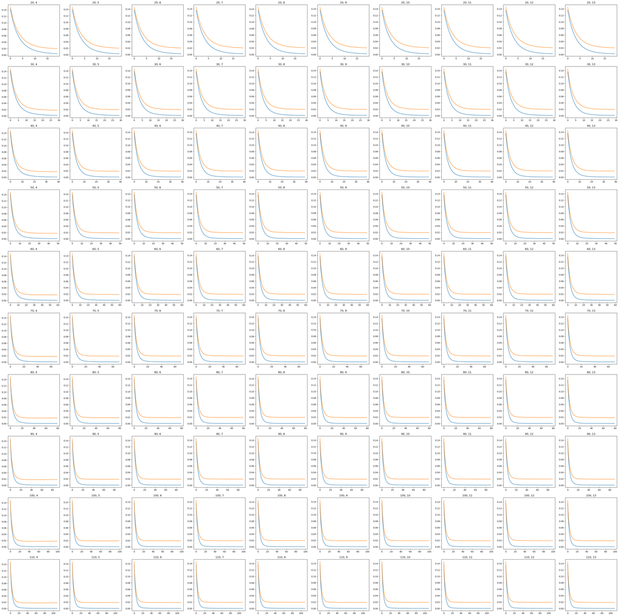

```python
fig, axs = plt.subplots(10, 10, figsize=(50, 50))
for i in range(10):
    for j in range(10):
        model = XGBClassifier(n_estimators = 20+10*i, max_depth = 4+j)
        evalset = [(X_train, y_train_bnr), (X_test,y_test_bnr)]
        model.fit(X_train, y_train_bnr, eval_set=evalset, verbose=False)
        model.set_params(eval_metric = 'logloss')
        y_pred_xgb = model.predict(X_test)
        score = accuracy_score(y_test_bnr, y_pred_xgb)
        results = model.evals_result()

        axs[i, j].plot(results['validation_0']['logloss'], label='train')
        axs[i, j].plot(results['validation_1']['logloss'], label='test')
        axs[i, j].set_title(str(20+10*i) + ', ' + str(4+j))
```

It is not easy to detect at sight. n_estimators should not be increased as curve flats out. I will get the values only and then decide which values I will use.

```python
print(results['validation_1']['logloss'][55])
```

```
0.01886479662266028
```

It refers to values of 70 and 8.

```python
xgb = XGBClassifier(n_estimators = 70, max_depth = 8)
xgb.fit(X_train, y_train_bnr)
y_pred_xgb = xgb.predict(X_test)
accuracy_score(y_test_bnr, y_pred_xgb)
```

```
0.8601667735728031
```

## Cross-validation

```python
from sklearn.model_selection import KFold
from sklearn.model_selection import cross_val_score
from numpy import mean
from numpy import absolute
from numpy import sqrt
cv = KFold(n_splits=10, random_state=1, shuffle=True)
for clf in [knn, dt, rf, xgb]:
    scores = cross_val_score(clf, X, y if clf == knn else y_bnr, scoring='neg_mean_absolute_error', cv=cv, n_jobs=-1)
    print(clf, ' : ', mean(absolute(scores)))
```

```
KNeighborsClassifier(n_neighbors=9)  :  0.8592806359237681
DecisionTreeClassifier(min_samples_leaf=5)  :  0.013067187741326184
RandomForestClassifier(max_features=160)  :  0.0062301970107835605
XGBClassifier(base_score=None, booster=None, callbacks=None,
              colsample_bylevel=None, colsample_bynode=None,
              colsample_bytree=None, device=None, early_stopping_rounds=None,
              enable_categorical=False, eval_metric=None, feature_types=None,
              gamma=None, grow_policy=None, importance_type=None,
              interaction_constraints=None, learning_rate=None, max_bin=None,
              max_cat_threshold=None, max_cat_to_onehot=None,
              max_delta_step=None, max_depth=8, max_leaves=None,
              min_child_weight=None, missing=nan, monotone_constraints=None,
              multi_strategy=None, n_estimators=70, n_jobs=None,
              num_parallel_tree=None, random_state=None, ...)  :  0.005327418705516859
```

## Conclusion

```python
for clf in [[knn, y_pred_knn], [dt, y_pred_dt], [rf, y_pred_rf], [xgb, y_pred_xgb]]:
    print(clf[0], ' : ', accuracy_score(y_test if clf[0] == knn else y_test_bnr, clf[1]))
```

```
KNeighborsClassifier(n_neighbors=9)  :  0.9211032713277743
DecisionTreeClassifier(min_samples_leaf=5)  :  0.7902501603592046
RandomForestClassifier(max_features=160)  :  0.8409236690186017
XGBClassifier(base_score=None, booster=None, callbacks=None,
              colsample_bylevel=None, colsample_bynode=None,
              colsample_bytree=None, device=None, early_stopping_rounds=None,
              enable_categorical=False, eval_metric=None, feature_types=None,
              gamma=None, grow_policy=None, importance_type=None,
              interaction_constraints=None, learning_rate=None, max_bin=None,
              max_cat_threshold=None, max_cat_to_onehot=None,
              max_delta_step=None, max_depth=8, max_leaves=None,
              min_child_weight=None, missing=nan, monotone_constraints=None,
              multi_strategy=None, n_estimators=70, n_jobs=None,
              num_parallel_tree=None, random_state=None, ...)  :  0.8601667735728031
```